# 02_logit_model

### 2.2 1.2 Out-of-sample re-validation of the encoding choice

The comparison above is an *in-sample* criterion computed on the same n = 1213 rows used to fit both models. Before treating it as final, we score both fits on the held-out test set using the posterior draws we already have – no new MCMC required, just posterior-mean predicted probabilities against the outcome the models never saw.

```r
# Held-out test set, same preprocessing pipeline as the training file --
# adjust the path / column names below if your test export differs
test <- read.csv("../data/airline_test_holdout.csv", stringsAsFactors = FALSE)
test$y <- as.integer(test$satisfaction == "satisfied")

# Standardize test covariates using TRAINING mean/sd -- never re-scale on test data
std_with <- function(x, m, s) (x - m) / s

Age_std_test        <- std_with(test$age, mean(train$age), sd(train$age))
Seat_std_test       <- std_with(test$seat_comfort, mean(train$seat_comfort), sd(train$seat_comfort))
FlightDist_std_test <- std_with(test$flight_distance, mean(train$flight_distance), sd(train$flight_distance))
logdep_std_test     <- std_with(test$log_dep_delay, mean(train$log_dep_delay), sd(train$log_dep_delay))
logmid_test         <- std_with(test$log_mid_delay, mean(train$log_mid_delay), sd(train$log_mid_delay))

TypeTravel_Personal_test <- as.integer(test$travel_type == "Personal Travel")
CustType_disloyal_test   <- as.integer(test$customer_type == "disloyal Customer")

Class_EcoPlus_test  <- as.integer(test$class == "Eco Plus")
Class_Business_test <- as.integer(test$class == "Business")

class_int_train <- as.integer(factor(train$class, levels = c("Eco", "Eco Plus", "Business"), ordered = TRUE))
class_int_test  <- as.integer(factor(test$class,  levels = c("Eco", "Eco Plus", "Business"), ordered = TRUE))
Class_score_std_test <- std_with(class_int_test, mean(class_int_train), sd(class_int_train))

X_dummy_test   <- cbind(Age_std_test, Seat_std_test, FlightDist_std_test,
                        Class_EcoPlus_test, Class_Business_test,
                        logdep_std_test, TypeTravel_Personal_test, CustType_disloyal_test)
X_ordinal_test <- cbind(Age_std_test, Seat_std_test, FlightDist_std_test, Class_score_std_test,
                        logdep_std_test, TypeTravel_Personal_test, CustType_disloyal_test)

# Posterior-mean predicted probability on the test set, averaged over the MCMC
# draws we already have -- reuses fit_dummy_logit / fit_ordinal_logit from 1.1
predict_p <- function(fit, X, arr_delay) {
  sm         <- as.matrix(fit)
  beta0_dr   <- sm[, "beta0"]
  beta_dr    <- sm[, grep("^beta\\[", colnames(sm)), drop = FALSE]
  betaarr_dr <- sm[, "beta_arr"]
  eta <- beta0_dr + beta_dr %*% t(X) + outer(betaarr_dr, arr_delay)
  colMeans(plogis(eta))
}

p_dummy_test   <- predict_p(fit_dummy_logit,   X_dummy_test,   logmid_test)
p_ordinal_test <- predict_p(fit_ordinal_logit, X_ordinal_test, logmid_test)

# Out-of-sample scoring: log-loss, Brier score, AUC (rank-based, no extra package)
auc_manual <- function(p, y) {
  r  <- rank(p)
  n1 <- as.numeric(sum(y == 1))
  n0 <- as.numeric(sum(y == 0))
  (sum(r[y == 1]) - n1 * (n1 + 1) / 2) / (n1 * n0)
}

oos_metrics <- function(p, y) {
  eps <- 1e-9
  p <- pmin(pmax(p, eps), 1 - eps)
  c(log_loss = -mean(y * log(p) + (1 - y) * log(1 - p)),
    brier    = mean((p - y)^2),
    auc      = auc_manual(p, y))
}

oos_cmp <- rbind(
  dummy   = oos_metrics(p_dummy_test,   test$y),
  ordinal = oos_metrics(p_ordinal_test, test$y)
)
knitr::kable(round(oos_cmp, 4))
```

|  | log_loss | brier | auc |
| --- | --- | --- | --- |
| dummy | 0.5571 | 0.1874 | 0.7865 |
| ordinal | 0.5616 | 0.1896 | 0.7809 |

## 3 2. MCMC diagnostic

```r
final_fit <- fit_dummy_logit

beta_cols <- colnames(as.matrix(final_fit))[!grepl("^log_lik", colnames(as.matrix(final_fit)))]

gd  <- gelman.diag(final_fit[, beta_cols])
gd
```

```
## Potential scale reduction factors:
##
##          Point est. Upper C.I.
## beta[1]        1.00       1.00
## beta[2]        1.00       1.00
## beta[3]        1.00       1.00
## beta[4]        1.00       1.01
## beta[5]        1.01       1.02
## beta[6]        1.00       1.00
## beta[7]        1.01       1.02
## beta[8]        1.00       1.00
## beta0          1.01       1.03
## beta_arr       1.00       1.00
##
## Multivariate psrf
##
## 1.01
```

```r
diag_df <- data.frame(
  ESS = effectiveSize(final_fit[, beta_cols])
)
knitr::kable(diag_df)
```

|  | ESS |
| --- | --- |
| beta[1] | 4977.473 |
| beta[2] | 5704.809 |
| beta[3] | 5142.000 |
| beta[4] | 4338.770 |
| beta[5] | 2588.322 |
| beta[6] | 5142.000 |
| beta[7] | 2310.824 |
| beta[8] | 4739.880 |
| beta0 | 2008.263 |
| beta_arr | 4807.533 |

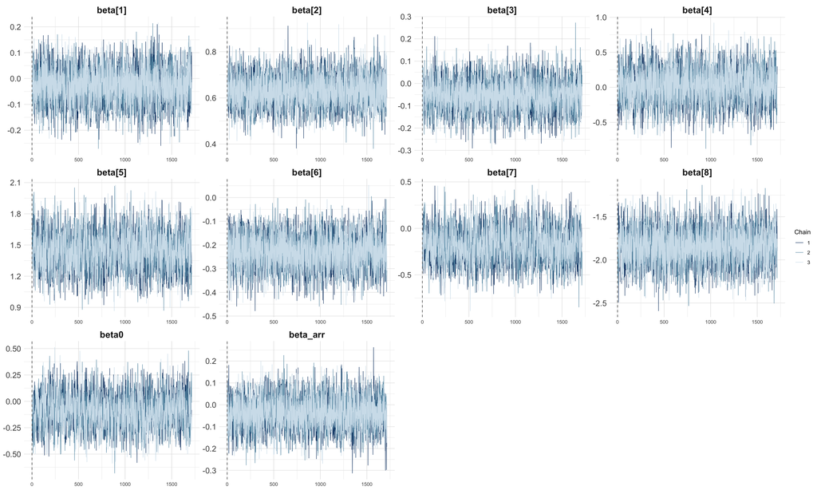

```r
mcmc_trace(final_fit[, beta_cols]) +
theme_minimal(base_size = 11) +
  theme(
    strip.text = element_text(size = 16, face = "bold"),
    axis.text.y = element_text(size = 14),
    panel.grid.major.x = element_line(color = "grey85", linewidth = 0.3)
  ) +
  vline_0(color = "grey40", linetype = "dashed")
```

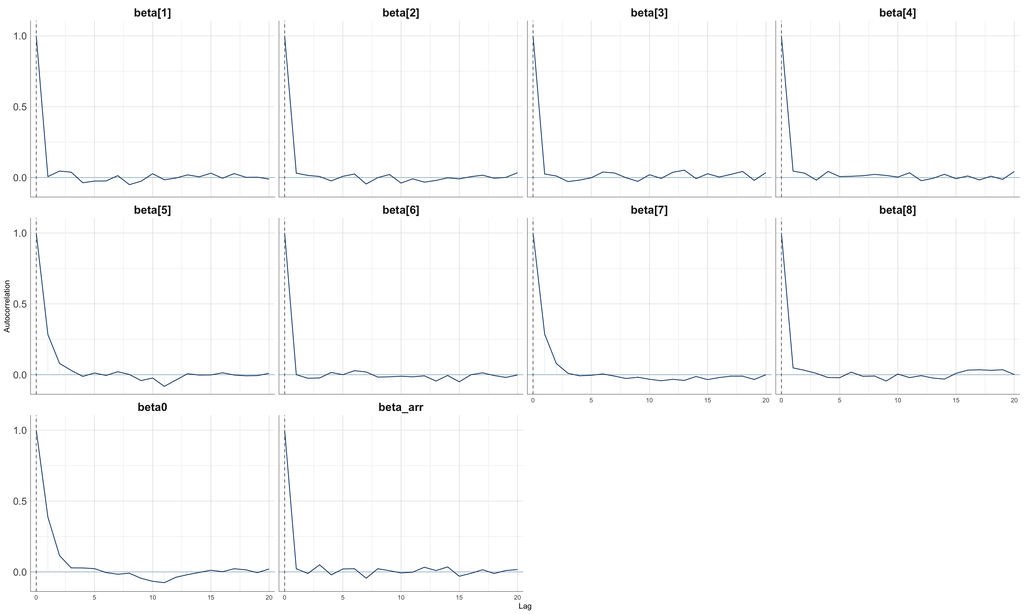

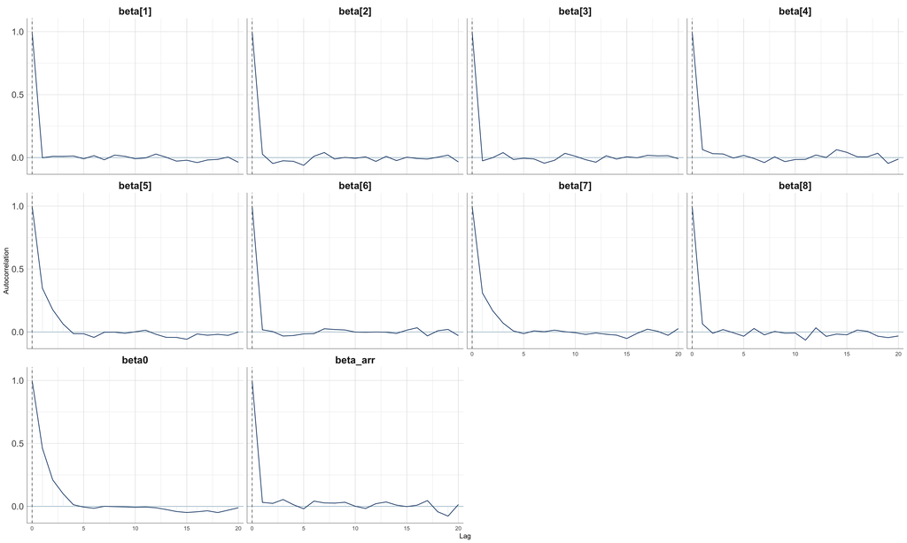

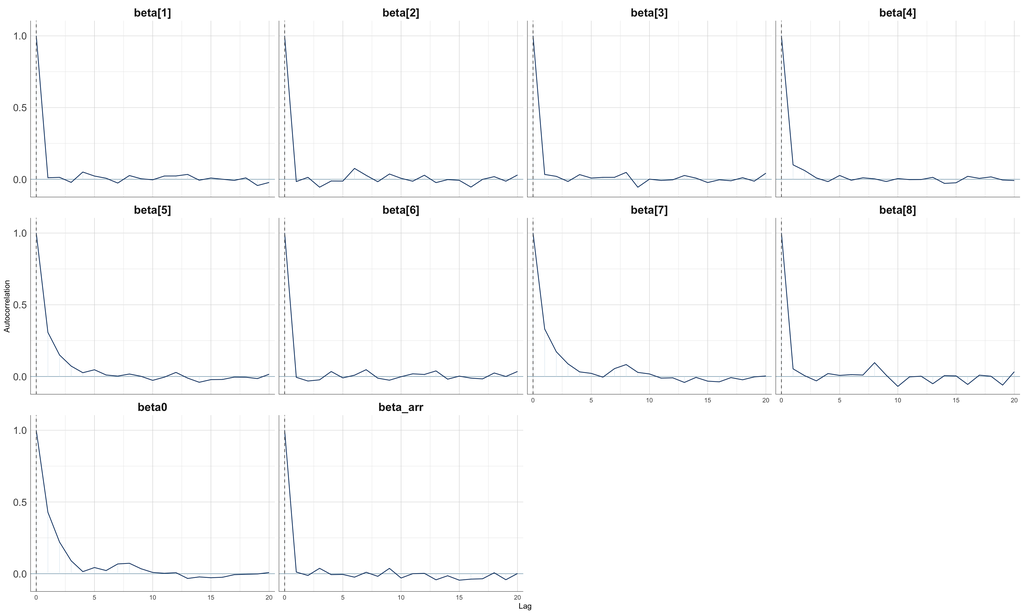

```r
for(i in 1:n_chains){
  print(
    mcmc_acf(final_fit[[i]][, beta_cols]) +
      theme_minimal(base_size = 11) +
      theme(
        strip.text = element_text(size = 16, face = "bold"),
        axis.text.y = element_text(size = 14),
        panel.grid.major.x = element_line(color = "grey85", linewidth = 0.3)
      ) +
      vline_0(color = "grey40", linetype = "dashed")
  )
}
```

## 4 3. MCMC results

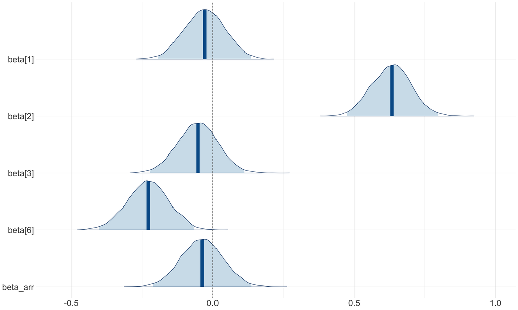

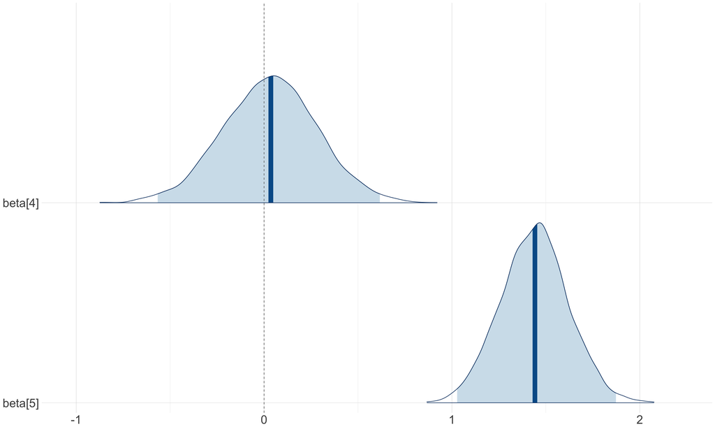

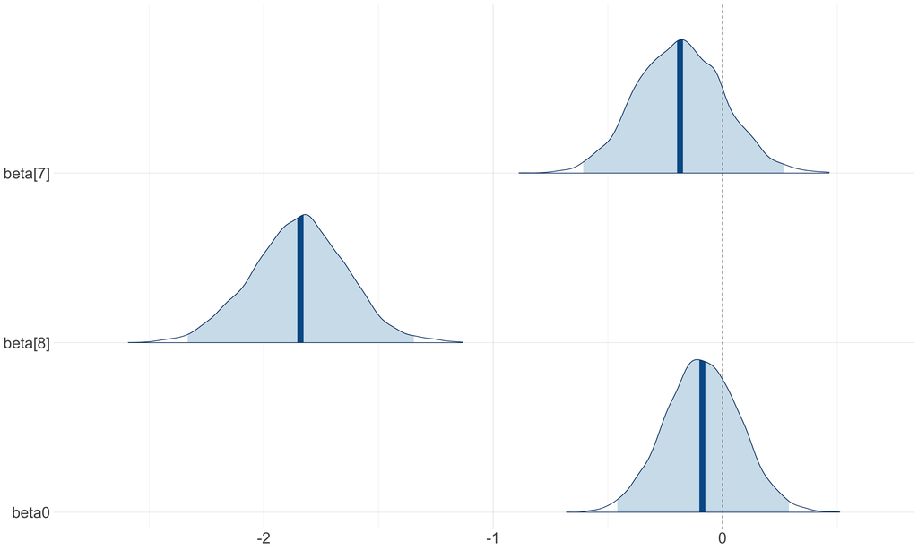

```r
groups <- list(
  continuous = c("beta[1]", "beta[2]", "beta[3]", "beta[6]", "beta_arr"),
  class      = c("beta[4]", "beta[5]"),
  binary     = c("beta[7]", "beta[8]", "beta0")
)

for (g in groups) {
  print(
    mcmc_areas(final_fit[, g], prob = 0.98) +
    theme_minimal(base_size = 11) +
      theme(
        axis.text.y = element_text(size = 24),
        axis.text.x = element_text(size = 24),
        panel.grid.major.x = element_line(color = "grey85", linewidth = 0.3)
      ) +
    vline_0(color = "grey40", linetype = "dashed")
        )
}
```

```r
sm <- as.matrix(final_fit)
sm_beta <- sm[, beta_cols]

term_labels <- c(
  "beta0" = "Intercept",
  "beta[1]" = "Age",
  "beta[2]" = "Seat comfort",
  "beta[3]" = "Flight Distance",
  "beta[4]" = "Class: Eco Plus (vs Eco)",
  "beta[5]" = "Class: Business (vs Eco)",
  "beta[6]" = "log(1+Departure Delay)",
  "beta[7]" = "Personal Travel (vs Business travel)",
  "beta[8]" = "disloyal Customer (vs Loyal)",
  "beta_arr" = "Mid-flight delay (signed-log)"
)

post_mean <- colMeans(sm_beta)
post_ci   <- apply(sm_beta, 2, quantile, c(0.025, 0.975))

or_tbl <- data.frame(
  term = term_labels[names(post_mean)],
  beta_mean = round(post_mean, 3),
  beta_lo = round(post_ci[1, ], 3), beta_hi = round(post_ci[2, ], 3),
  OR = round(exp(post_mean), 3),
  OR_lo = round(exp(post_ci[1, ]), 3), OR_hi = round(exp(post_ci[2, ]), 3)
) %>% arrange(desc(OR))

knitr::kable(or_tbl, row.names = FALSE)
```

| term | beta_mean | beta_lo | beta_hi | OR | OR_lo | OR_hi |
| --- | --- | --- | --- | --- | --- | --- |
| Class: Business (vs Eco) | 1.440 | 1.088 | 1.791 | 4.221 | 2.967 | 5.993 |
| Seat comfort | 0.632 | 0.497 | 0.769 | 1.882 | 1.644 | 2.157 |
| Class: Eco Plus (vs Eco) | 0.032 | -0.467 | 0.525 | 1.033 | 0.627 | 1.691 |
| Age | -0.028 | -0.166 | 0.108 | 0.972 | 0.847 | 1.114 |
| Mid-flight delay (signed-log) | -0.038 | -0.182 | 0.108 | 0.963 | 0.833 | 1.114 |
| Flight Distance | -0.053 | -0.192 | 0.086 | 0.949 | 0.825 | 1.090 |
| Intercept | -0.087 | -0.405 | 0.233 | 0.917 | 0.667 | 1.262 |
| Personal Travel (vs Business travel) | -0.184 | -0.546 | 0.189 | 0.832 | 0.580 | 1.208 |
| log(1+Departure Delay) | -0.229 | -0.373 | -0.089 | 0.795 | 0.689 | 0.914 |
| disloyal Customer (vs Loyal) | -1.845 | -2.257 | -1.439 | 0.158 | 0.105 | 0.237 |

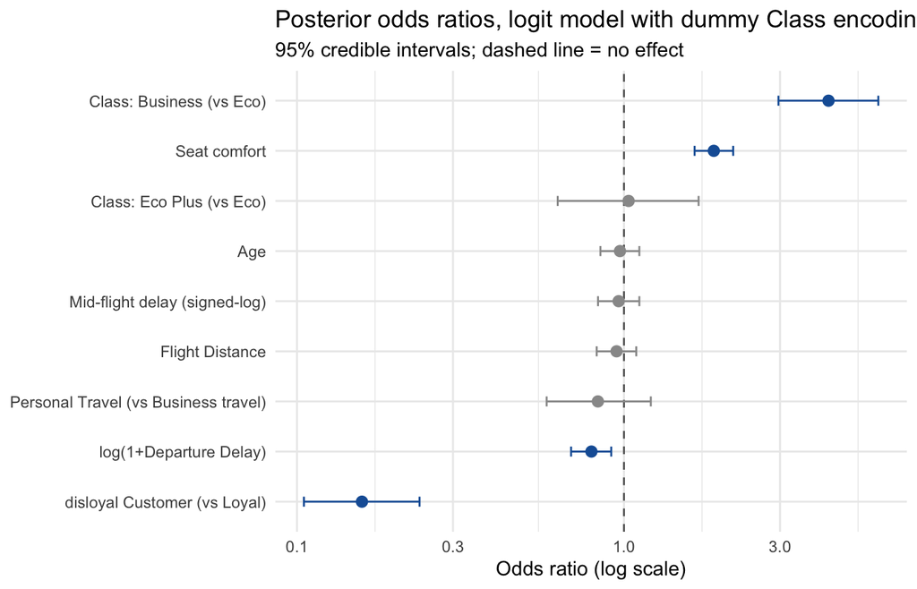

```r
or_tbl %>%
  filter(term != "Intercept") %>%
  mutate(term = factor(term, levels = term[order(OR)]),
         significant = OR_lo > 1 | OR_hi < 1) %>%
  ggplot(aes(x = OR, y = term, color = significant)) +
  geom_vline(xintercept = 1, linetype = "dashed", color = "grey40") +
  geom_errorbarh(aes(xmin = OR_lo, xmax = OR_hi), height = 0.2) +
  geom_point(size = 2.5) +
  scale_color_manual(values = c("TRUE" = "#185FA5", "FALSE" = "grey60"), guide = "none") +
  scale_x_log10() +
  labs(title = "Posterior odds ratios, logit model with dummy Class encoding",
       subtitle = "95% credible intervals; dashed line = no effect",
       x = "Odds ratio (log scale)", y = NULL) +
  theme_minimal(base_size = 11)
```

## 5 4. Interpretation

`Business` class carries by far the largest effect (OR $\approx$ 4.221, 95% CI [2.967, 5.993]), confirming the Section 01 subgroup contrast even after adjusting for everything else. `disloyal Customer` shows a strong *negative* effect (OR $\approx$ 0.158), also consistent with Section 01. `Seat comfort` is the strongest continuous driver.

## 6 5. Result export

Export results for later usage.

```r
final_loglik <- extract_loglik(final_fit)
loo_final <- loo::loo(final_loglik)
waic_final <- loo::waic(final_loglik)

sm_final <- as.matrix(final_fit)
beta_draws <- sm_final[, beta_cols]

standardization <- list(
  Age_mean = mean(train$age), Age_sd = sd(train$age),
  Seat_mean = mean(train$seat_comfort), Seat_sd = sd(train$seat_comfort),
  FlightDist_mean = mean(train$flight_distance), FlightDist_sd = sd(train$flight_distance),
  logdep_mean = mean(train$log_dep_delay), logDepDelay_sd = sd(train$log_dep_delay),
  logmid_mean = mean(train$log_mid_delay), logmid_sd = sd(train$log_mid_delay)
)

saveRDS(list(
  loo = loo_final,
  waic = waic_final,
  beta_mean = post_mean,
  beta_ci = post_ci,
  or_tbl = or_tbl,
  beta_draws = beta_draws,
  standardization = standardization
), "../data/02_logit_mcmc.rds")
```